# MTH6139 Time Series

Coursework 1 – Prophet Forecasting Project

Muhammad Taha Khan

March 12, 2026

# 1 Introduction

The aim of this project is to analyze a given time series data set and forecast it using the Prophet Forecasting System developed by Meta.

The data set used in this project is the built-in data set **co2** available in R. The data set represents monthly atmospheric carbon dioxide concentrations observed at Mauna Loa Observatory in Hawaii.

# 2 Exploring the Dataset

```r
data(co2)

start(co2)
```

```
## [1] 1959    1
```

```r
end(co2)
```

```
## [1] 1997   12
```

```r
frequency(co2)
```

```
## [1] 12
```

The dataset begins in 1959 and contains monthly observations of atmospheric CO₂ levels.

# 3 Visualising the Time Series

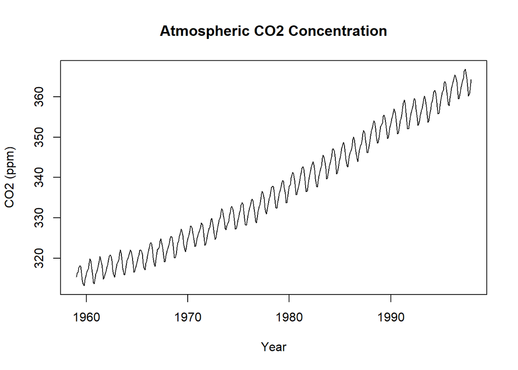

```r
plot(co2,
     main = "Atmospheric CO2 Concentration",
     xlab = "Year",
     ylab = "CO2 (ppm)")
```

The plot shows a clear upward trend in atmospheric carbon dioxide levels along with a repeating seasonal pattern.

# 4 Preparing the Data for Prophet

```r
library(prophet)
library(zoo)
time_values <- time(co2)
date_values <- as.Date(as.yearmon(time_values))

co2_dataframe <- data.frame(
  ds = date_values,
  y = as.numeric(co2)
)

head(co2_dataframe)
```

```
##           ds      y
## 1 1959-01-01 315.42
## 2 1959-02-01 316.31
## 3 1959-03-01 316.50
## 4 1959-04-01 317.56
## 5 1959-05-01 318.13
## 6 1959-06-01 318.00
```

Prophet requires the data to be stored in a dataframe with two columns: **ds** (date) and **y** (value).

# 5 Building the Prophet Model

```r
prophet_model <- prophet(co2_dataframe)
```

```
## Disabling weekly seasonality. Run prophet with weekly.seasonality=TRUE to override this.
```

```
## Disabling daily seasonality. Run prophet with daily.seasonality=TRUE to override this.
```

Prophet automatically detects long-term trends and seasonal patterns.

# 6 Forecasting Future Values

```r
future_dates <- make_future_dataframe(prophet_model,
                                      periods = 24,
                                      freq = "month")

forecast_results <- predict(prophet_model, future_dates)

head(forecast_results)
```

```
##           ds    trend additive_terms additive_terms_lower additive_terms_upper
## 1 1959-01-01 315.3626     -0.0775880           -0.0775880           -0.0775880
## 2 1959-02-01 315.4469      0.5946394            0.5946394            0.5946394
## 3 1959-03-01 315.5230      1.2325855            1.2325855            1.2325855
## 4 1959-04-01 315.6073      2.4609156            2.4609156            2.4609156
## 5 1959-05-01 315.6888      3.0206586            3.0206586            3.0206586
## 6 1959-06-01 315.7731      2.3515302            2.3515302            2.3515302
##       yearly yearly_lower yearly_upper multiplicative_terms
## 1 -0.0775880   -0.0775880   -0.0775880                    0
## 2  0.5946394    0.5946394    0.5946394                    0
## 3  1.2325855    1.2325855    1.2325855                    0
## 4  2.4609156    2.4609156    2.4609156                    0
## 5  3.0206586    3.0206586    3.0206586                    0
## 6  2.3515302    2.3515302    2.3515302                    0
##   multiplicative_terms_lower multiplicative_terms_upper yhat_lower yhat_upper
## 1                          0                          0   314.8084   315.7393
## 2                          0                          0   315.5727   316.5162
## 3                          0                          0   316.2826   317.2115
## 4                          0                          0   317.6122   318.5148
## 5                          0                          0   318.2027   319.1561
## 6                          0                          0   317.6363   318.5848
##   trend_lower trend_upper     yhat
## 1    315.3626    315.3626 315.2850
## 2    315.4469    315.4469 316.0415
## 3    315.5230    315.5230 316.7556
## 4    315.6073    315.6073 318.0682
## 5    315.6888    315.6888 318.7095
## 6    315.7731    315.7731 318.1247
```

The model forecasts CO₂ levels for the next 24 months.

# 7 Forecast Plot

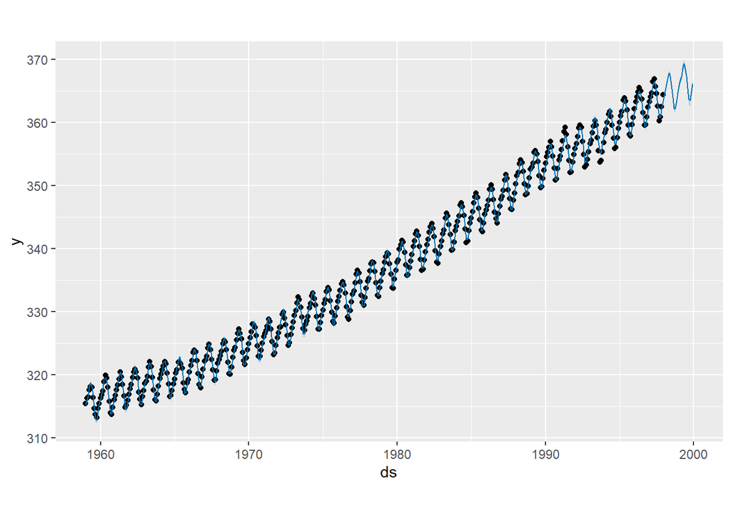

```r
plot(prophet_model, forecast_results)
```

The dark line represents predicted values, while the shaded region represents uncertainty intervals.

# 8 Model Components

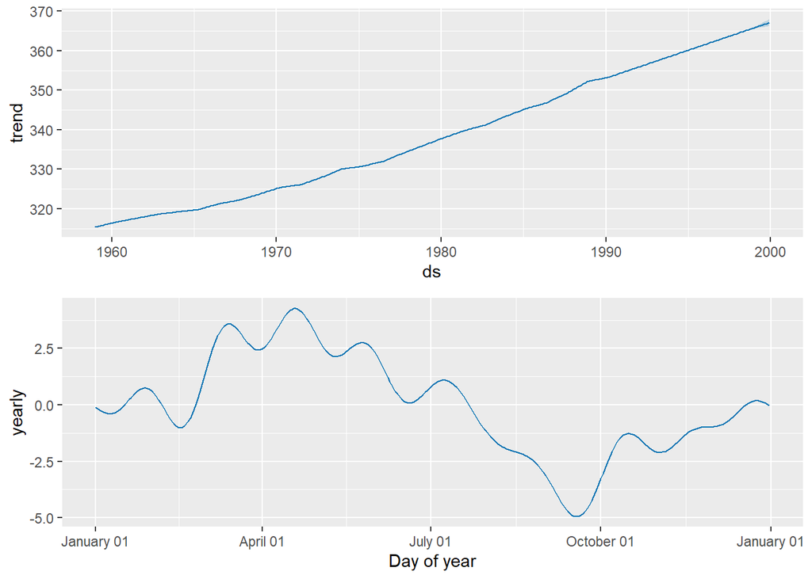

```r
prophet_plot_components(prophet_model, forecast_results)
```

This shows the trend and seasonal components of the model.

# 9 Conclusion

This project used the Prophet forecasting system to analyze the atmospheric CO₂ data. The data has a strong upward trend and clear yearly seasonality. The forecast indicates that CO₂ levels will continue to rise if the current trends persist.

# References

Prophet Documentation  
https://facebook.github.io/prophet/

R Markdown Documentation  
https://rmarkdown.rstudio.com